# Part 3 - Introduction to Pandas

# Table of Contents

## Introduction to Pandas

In the previous notebook, we dove into the details on [NumPy](https://numpy.org/), which provides efficient storage and ability to perform complex computations through its `ndarray` object for working with homogeneous numerical array data. Here, we will build on the knowledge by looking into the data structures provided by **[Pandas](https://pandas.pydata.org/)**.

**[Pandas](https://pandas.pydata.org/)** provides high-level data structures and functions designed to make working with structured or tabular data fast, easy, and expressive. It is based on two main data structures:

- `Series`: one-dimensional such as a list of items
- `DataFrame`: two-dimensional, such as a table

Both `Series` and `DataFrame` objects build on the NumPy array structure and form the core data model for Pandas in Python. While NumPy is best suited for working with homogeneous data, Pandas is designed for working with tabular or heterogeneous data. NumPy serves its purpose very well when the data is well organized and clean, however its limitations become clear when working with less structured data where we need more flexibility such as attaching labels to data, working with missing data, grouping, pivoting etc.

Pandas blends the high-performance, array-computing ideas of NumPy with the flexible data manipulation capabilities of relational databases (such as SQL). Pandas provides sophisticated indexing functionality to reshape, slice and dice, perform aggregations, and select subsets of data. It also provides capabilities for easily handling missing data, adding/deleting columns, imputing missing data, and creating plots on the go. Pandas is a must-have tool for data wrangling and manipulation.

### Installation and Import

A typical installation of Python API comes with Pandas. You can import it as:

```python
import pandas as pd
import numpy as np
```

You can also check the version of Pandas that is installed:

```python
pd.__version__
```

```
'1.0.5'
```

## Working with Series

A Pandas `Series` is a one-dimensional array of indexed data. A `Series` object contains a sequence of values and an associated array of data labels, called `index`. While Numpy Array has an implicitly defined integer index that can be used to access the values, the index for a Pandas `Series` can also be explicitly defined. Let's take a look at some examples.

### Creating Series from a List or Array

A `Series` can be created from a list or array as follows:

```python
# Create Series
data1 = [1,2,3,6,7]
s1 = pd.Series(data1)
s1
```

```
0    1
1    2
2    3
3    6
4    7
dtype: int64
```

The array representation and index object of the `Series` can be accessed via its `values` and `index` attributes:

```python
print('Values in series s1:', s1.values)
print('Index of series s1:', s1.index)
```

```
Values in series s1: [1 2 3 6 7]
Index of series s1: RangeIndex(start=0, stop=5, step=1)
```

Like NumPy arrays, data in a `Series` can be accessed by the associated index.

```python
# Access elements of a Series
print(s1[0])
print(s1[3])
```

```
1
6
```

For `Series` objects, the index need not be an integer and can be explicitly defined as follows:

```python
s2 = pd.Series([1,2,3,6,7], index=['d', 'b', 'a', 'c', 'e'])
s2
```

```
d    1
b    2
a    3
c    6
e    7
dtype: int64
```

```python
# Check the index
s2.index
```

```
Index(['d', 'b', 'a', 'c', 'e'], dtype='object')
```

```python
# Access elements using index label

print('Element associated with index a:', s2['a'])
print('Element associated with index e:', s2['e'])
```

```
Element associated with index a: 3
Element associated with index e: 7
```

```python
# Access elements using index position

print('Element associated with index position 2:', s2[2])
print('Element associated with last index position:', s2[-1])
```

```
Element associated with index position 2: 3
Element associated with last index position: 7
```

### Creating Series from a Dictionary

Just like a dictionary maps keys to a set of values, a series can be thought of as a mapping of index values to data values. Let's create a series from a dictionary.

```python
data = {'CA': 35000, 'TX': 71000, 'WA': 16000, 'OR': 5000}
s3 = pd.Series(data)
s3
```

```
CA    35000
TX    71000
WA    16000
OR     5000
dtype: int64
```

By default, index for `Series` will be created using the keys.

```python
# Access elements using index label
s3['CA']
```

```
35000
```

```python
# Access elements using index position
s3[0]
```

```
35000
```

## Working with DataFrame

A [`DataFrame`](https://pandas.pydata.org/pandas-docs/stable/user_guide/dsintro.html) represents a rectangular table of data and contains an ordered collection of columns. You can think of it as a spreadsheet or SQL table where each column has a column name for reference and each row can be accessed by using row numbers. Column names and row numbers are known as column and row index.

DataFrame is a fundamental **Pandas** data structure in which each column can be of a different value type (numeric, string, boolean, etc.). A data set can be first read into a DataFrame and then various operations (i.e. indexing, grouping, aggregation etc.) can be easily applied to it.

### Creating a DataFrame

There are many ways to construct a DataFrame. Let's look at some examples.

#### From a Dictionary

`DataFrame` can be constructed from a dictionary of equal sized lists or NumPy arrays.

```python
data = {'state':['CA','WA','CA','WA','CA','WA'],
        'year':[2015,2015,2016,2016,2017,2017],
        'population':[38.5,7.0,39.0,7.25,39.5,7.5]}

df1 = pd.DataFrame(data)
df1
```

|  | state | year | population |
| --- | --- | --- | --- |
| 0 | CA | 2015 | 38.50 |
| 1 | WA | 2015 | 7.00 |
| 2 | CA | 2016 | 39.00 |
| 3 | WA | 2016 | 7.25 |
| 4 | CA | 2017 | 39.50 |
| 5 | WA | 2017 | 7.50 |

#### From a Series

`DataFrame` is a collection of `Series` objects. Let's look at constructing a `DataFrame` from a single `Series` object.

```python
# Create Population series
pop_data = {'CA': 39.5,'TX': 29,'NY': 8.39,'FL': 21.48,
            'IL': 12.67}
population = pd.Series(pop_data)
```

```python
# Create DataFrame from series
pop_df = pd.DataFrame(population, columns=['population'])
pop_df
```

|  | population |
| --- | --- |
| CA | 39.50 |
| TX | 29.00 |
| NY | 8.39 |
| FL | 21.48 |
| IL | 12.67 |

#### From a Dictionary of Series

`DataFrame` can also be constructed from a dictionary of `Series`.

```python
# Create Area series
area_data = {'CA': 155779.22, 'TX': 261231.71, 'NY': 47126.40,
             'FL': 53624.76, 'IL': 55518.93}
area = pd.Series(area_data)
area
```

```
CA    155779.22
TX    261231.71
NY     47126.40
FL     53624.76
IL     55518.93
dtype: float64
```

```python
# Create DataFrame from dictionary of Series
df2 = pd.DataFrame({'population':population,
                   'land area':area})
df2
```

|  | population | land area |
| --- | --- | --- |
| CA | 39.50 | 155779.22 |
| TX | 29.00 | 261231.71 |
| NY | 8.39 | 47126.40 |
| FL | 21.48 | 53624.76 |
| IL | 12.67 | 55518.93 |

#### From a two-dimensional NumPy Array

`DataFrame` can be constructed from a two-dimensional NumPy array by specifying the column names. An integer `Index` is used if not specified.

```python
pd.DataFrame(np.random.rand(4, 2),
             columns=['Col_A', 'Col_B'],
             index=['a', 'b', 'c', 'd'])
```

|  | Col_A | Col_B |
| --- | --- | --- |
| a | 0.028278 | 0.687096 |
| b | 0.999634 | 0.443590 |
| c | 0.750714 | 0.785287 |
| d | 0.611652 | 0.651515 |

### Importing Data into a DataFrame

Reading data into a `DataFrame` is one of the most common task in any data scinece problem. **Pandas** provides the ability to read data from various formats such as CSV, JSON, Excel, APIs, etc. directly into a `DataFrame` object. Let's look at how to read data from some common formats into a `DataFrame`.

#### Read from a csv

`read_csv()` function can be used to read csv (comma-separated value) files. The function includes a number of different parameters and you can read more about them in the pandas documentation [here](https://pandas.pydata.org/pandas-docs/stable/reference/api/pandas.read_csv.html).

Let's import the 'health.csv' file we used earlier in this guide series.

```python
# Read the data from csv
df_csv = pd.read_csv('../data/health.csv')
df_csv.head()
```

|  | Number of Beds | Name | Address | City | State | Zip Code |
| --- | --- | --- | --- | --- | --- | --- |
| 0 | 156 | Facility 1 | 2468 SOUTH ST ANDREWS PLACE | LOS ANGELES | CA | 90018 |
| 1 | 59 | Facility 2 | 2300 W. WASHINGTON BLVD. | LOS ANGELES | CA | 90018 |
| 2 | 25 | Facility 3 | 4060 E. WHITTIER BLVD. | LOS ANGELES | CA | 90023 |
| 3 | 49 | Facility 4 | 6070 W. PICO BOULEVARD | LOS ANGELES | CA | 90035 |
| 4 | 55 | Facility 5 | 1480 S. LA CIENEGA BL | LOS ANGELES | CA | 90035 |

```python
# Confirm type
type(df_csv)
```

```
pandas.core.frame.DataFrame
```

#### Read from an excel file

Tabular data is often stored using Microsoft Excel 2003 (and higher) and can be read using `read_excel()`.

```python
# Read the data from excel
df_excel = pd.read_excel('../data/health.xlsx')
df_excel
```

|  | Number of Beds | Name | Address | City | State | Zip Code |
| --- | --- | --- | --- | --- | --- | --- |
| 0 | 156 | Facility 1 | 2468 SOUTH ST ANDREWS PLACE | LOS ANGELES | CA | 90018 |
| 1 | 59 | Facility 2 | 2300 W. WASHINGTON BLVD. | LOS ANGELES | CA | 90018 |
| 2 | 25 | Facility 3 | 4060 E. WHITTIER BLVD. | LOS ANGELES | CA | 90023 |
| 3 | 49 | Facility 4 | 6070 W. PICO BOULEVARD | LOS ANGELES | CA | 90035 |
| 4 | 55 | Facility 5 | 1480 S. LA CIENEGA BL | LOS ANGELES | CA | 90035 |

```python
# Confirm type
type(df_excel)
```

```
pandas.core.frame.DataFrame
```

#### Read from a json

`read_json()` can be used to read JSON (JavaScript Object Notation) files. JSON is mostly used to store unstructured data with key/value pairs. The function accepts a valid JSON string, path object or file-like object and does not consume a dictionay (key/value pair) directly. Let's read 'health.json' into a `DataFrame`.

```python
# Read the data from json
df_json = pd.read_json('../data/health.json')
df_json
```

|  | Number of Beds | Name | Address | City | State | Zip Code |
| --- | --- | --- | --- | --- | --- | --- |
| 0 | 156 | Facility 1 | 2468 SOUTH ST ANDREWS PLACE | LOS ANGELES | CA | 90018 |
| 1 | 59 | Facility 2 | 2300 W. WASHINGTON BLVD. | LOS ANGELES | CA | 90018 |
| 2 | 25 | Facility 3 | 4060 E. WHITTIER BLVD. | LOS ANGELES | CA | 90023 |
| 3 | 49 | Facility 4 | 6070 W. PICO BOULEVARD | LOS ANGELES | CA | 90035 |
| 4 | 55 | Facility 5 | 1480 S. LA CIENEGA BL | LOS ANGELES | CA | 90035 |

```python
# Confirm type
type(df_json)
```

```
pandas.core.frame.DataFrame
```

#### Read from an API

Many websites provide data through public APIs in json or other formats. One easy way to access these APIs from Python is using `requests` package. Let's find issues for pandas on GitHub using the add-on requests library.

```python
# Import library
import requests
```

```python
# Make request and store response
url = 'https://api.github.com/repos/pandas-dev/pandas/issues'
resp = requests.get(url)
```

The response object’s `json` method will return a dictionary containing JSON. `.keys()` method can be used to explore the structure of the returned JSON object.

```python
# Get json
json_data = resp.json()
json_data[0].keys()
```

```
dict_keys(['url', 'repository_url', 'labels_url', 'comments_url', 'events_url', 'html_url', 'id', 'node_id', 'number', 'title', 'user', 'labels', 'state', 'locked', 'assignee', 'assignees', 'milestone', 'comments', 'created_at', 'updated_at', 'closed_at', 'author_association', 'active_lock_reason', …
```

Since each element in `json_data` is a dictionary, you can create a DataFrame using specific columns from the data.

```python
# Create dataframe for specific cols
issues = pd.DataFrame(json_data, columns=['number', 'title',
                                   'labels', 'state', 'created_at'])
issues.head()
```

|  | number | title | labels | state | created_at |
| --- | --- | --- | --- | --- | --- |
| 0 | 38070 | BUG: Index.drop raising Error when Index has d... | [] | open | 2020-11-25T20:11:11Z |
| 1 | 38069 | ENH: Rename multi-level columns or indices usi... | [{'id': 76812, 'node_id': 'MDU6TGFiZWw3NjgxMg=... | open | 2020-11-25T19:57:28Z |
| 2 | 38068 | ENH: NDArrayBackedExtensionArray.__array_funct... | [] | open | 2020-11-25T18:32:41Z |
| 3 | 38067 | DOC: Include missing holiday observance rules | [{'id': 134699, 'node_id': 'MDU6TGFiZWwxMzQ2OT... | open | 2020-11-25T17:25:35Z |
| 4 | 38066 | RLS: 1.1.5 | [{'id': 131473665, 'node_id': 'MDU6TGFiZWwxMzE... | open | 2020-11-25T15:51:33Z |

To create a `DataFrame` with all the data directly from the response object, **"json"** library can be used. Since `read_json()` accepts a valid JSON string, `json.dumps()` can be used to convert the object back to a string.

```python
# Import library
import json
```

```python
# Read all data from response object's json method
all_issues = pd.read_json(json.dumps(json_data))
all_issues.head()
```

|  | url | repository_url | labels_url | comments_url | events_url | html_url | id | node_id | number | title | ... | milestone | comments | created_at | updated_at | closed_at | author_association | active_lock_reason | pull_request | body | performed_via_github_app |
| --- | --- | --- | --- | --- | --- | --- | --- | --- | --- | --- | --- | --- | --- | --- | --- | --- | --- | --- | --- | --- | --- |
| 0 | https://api.github.com/repos/pandas-dev/pandas... | https://api.github.com/repos/pandas-dev/pandas | https://api.github.com/repos/pandas-dev/pandas... | https://api.github.com/repos/pandas-dev/pandas... | https://api.github.com/repos/pandas-dev/pandas... | https://github.com/pandas-dev/pandas/pull/38070 | 751090409 | MDExOlB1bGxSZXF1ZXN0NTI3NjcwMDk4 | 38070 | BUG: Index.drop raising Error when Index has d... | ... | None | 0 | 2020-11-25 20:11:11+00:00 | 2020-11-25 20:39:16+00:00 | NaT | MEMBER | NaN | {'url': 'https://api.github.com/repos/pandas-d... | - [x] closes #38051\r\n- [x] closes #33494\r\n... | NaN |
| 1 | https://api.github.com/repos/pandas-dev/pandas... | https://api.github.com/repos/pandas-dev/pandas | https://api.github.com/repos/pandas-dev/pandas... | https://api.github.com/repos/pandas-dev/pandas... | https://api.github.com/repos/pandas-dev/pandas... | https://github.com/pandas-dev/pandas/issues/38069 | 751083108 | MDU6SXNzdWU3NTEwODMxMDg= | 38069 | ENH: Rename multi-level columns or indices usi... | ... | None | 0 | 2020-11-25 19:57:28+00:00 | 2020-11-25 19:57:28+00:00 | NaT | NONE | NaN | NaN | It's currently quite difficult to rename a sin... | NaN |
| 2 | https://api.github.com/repos/pandas-dev/pandas... | https://api.github.com/repos/pandas-dev/pandas | https://api.github.com/repos/pandas-dev/pandas... | https://api.github.com/repos/pandas-dev/pandas... | https://api.github.com/repos/pandas-dev/pandas... | https://github.com/pandas-dev/pandas/pull/38068 | 751038480 | MDExOlB1bGxSZXF1ZXN0NTI3NjI3Njc2 | 38068 | ENH: NDArrayBackedExtensionArray.__array_funct... | ... | None | 1 | 2020-11-25 18:32:41+00:00 | 2020-11-25 18:49:53+00:00 | NaT | MEMBER | NaN | {'url': 'https://api.github.com/repos/pandas-d... | motivated by getting np.delete and np.repeat w... | NaN |
| 3 | https://api.github.com/repos/pandas-dev/pandas... | https://api.github.com/repos/pandas-dev/pandas | https://api.github.com/repos/pandas-dev/pandas... | https://api.github.com/repos/pandas-dev/pandas... | https://api.github.com/repos/pandas-dev/pandas... | https://github.com/pandas-dev/pandas/issues/38067 | 750998859 | MDU6SXNzdWU3NTA5OTg4NTk= | 38067 | DOC: Include missing holiday observance rules | ... | None | 0 | 2020-11-25 17:25:35+00:00 | 2020-11-25 17:28:13+00:00 | NaT | NONE | NaN | NaN | #### Location of the documentation\r\n\r\n[Tim... | NaN |
| 4 | https://api.github.com/repos/pandas-dev/pandas... | https://api.github.com/repos/pandas-dev/pandas | https://api.github.com/repos/pandas-dev/pandas... | https://api.github.com/repos/pandas-dev/pandas... | https://api.github.com/repos/pandas-dev/pandas... | https://github.com/pandas-dev/pandas/issues/38066 | 750932114 | MDU6SXNzdWU3NTA5MzIxMTQ= | 38066 | RLS: 1.1.5 | ... | {'url': 'https://api.github.com/repos/pandas-d... | 3 | 2020-11-25 15:51:33+00:00 | 2020-11-25 16:11:36+00:00 | NaT | MEMBER | NaN | NaN | Tracking issue for the 1.1.5 release.\r\n\r\nh... | NaN |

5 rows × 26 columns

### Navigating a DataFrame

Elements or subsets of a `DataFrame` can be accessed in multiple ways. We can use `[]` or use slice notation, marked by the colon (`:`) character to access subsets of data. Indexing and slicing to select subsets of a DataFrame can be performed:

- By location, like lists
- By label, like dictionaries
- By boolean masks like NumPy arrays

Special indexing operators such as `loc` and `iloc` also enable selection of a subset of the rows and columns from a DataFrame. Let's look at some examples.

#### Selecting Columns

Columns of the DataFrame are essentially `Series` objects that can be accessed via dictionary-style indexing.

```python
df2['population']
```

```
CA    39.50
TX    29.00
NY     8.39
FL    21.48
IL    12.67
Name: population, dtype: float64
```

Individual columns can also be selected using attribute-style access.

```python
df2.population
```

```
CA    39.50
TX    29.00
NY     8.39
FL    21.48
IL    12.67
Name: population, dtype: float64
```

#### Selection using `loc` and `iloc`

Special indexing operators such as `loc` and `iloc` can be used to select a subset of the rows and columns from a DataFrame.

- `.loc` for label-based indexing can be used to index the data in an array-like style by specifying index and column names
- `.iloc` for positional indexing can be used to index the underlying array as if it is a simple NumPy array.

Let's add another column to `df2` DataFrame and then look at some examples.

```python
# Add column
df2['density'] = df2['population']*1000000 / df2['land area']
df2
```

|  | population | land area | density |
| --- | --- | --- | --- |
| CA | 39.50 | 155779.22 | 253.563986 |
| TX | 29.00 | 261231.71 | 111.012557 |
| NY | 8.39 | 47126.40 | 178.031846 |
| FL | 21.48 | 53624.76 | 400.561233 |
| IL | 12.67 | 55518.93 | 228.210450 |

**Selection using `.iloc`**

`.iloc` is used for positional indexing.

```python
# First two rows and all columns
df2.iloc[:2, :]
```

|  | population | land area | density |
| --- | --- | --- | --- |
| CA | 39.5 | 155779.22 | 253.563986 |
| TX | 29.0 | 261231.71 | 111.012557 |

```python
# Last two rows and first two columns
df2.iloc[-2:, :2]
```

|  | population | land area |
| --- | --- | --- |
| FL | 21.48 | 53624.76 |
| IL | 12.67 | 55518.93 |

```python
# Middle subset of rows and columns
df2.iloc[2:4, 1:2]
```

|  | land area |
| --- | --- |
| NY | 47126.40 |
| FL | 53624.76 |

**Selection using `.loc`**

`.loc` is used for label-based indexing by specifying index and column names.

```python
# Select rows until 'TX' and all columns
df2.loc[:'TX', :]
```

|  | population | land area | density |
| --- | --- | --- | --- |
| CA | 39.5 | 155779.22 | 253.563986 |
| TX | 29.0 | 261231.71 | 111.012557 |

```python
# Select rows from 'FL' and columns until 'area'
df2.loc['FL':, :'land area']
```

|  | population | land area |
| --- | --- | --- |
| FL | 21.48 | 53624.76 |
| IL | 12.67 | 55518.93 |

```python
# Middle subset of rows from NY to FL and columns from 'area' to 'density'
df2.loc['NY':'FL', 'land area':'density']
```

|  | land area | density |
| --- | --- | --- |
| NY | 47126.40 | 178.031846 |
| FL | 53624.76 | 400.561233 |

#### Conditional Selection

*Boolean masks* can be used to conditionally select specific subsets of the data. They select the elements of an `DataFrame` that satisfy some condition. Let's take a look.

```python
df2['density'] > 200
```

```
CA     True
TX    False
NY    False
FL     True
IL     True
Name: density, dtype: bool
```

```python
# Select data where density > 200
df2[df2['density'] > 200]
```

|  | population | land area | density |
| --- | --- | --- | --- |
| CA | 39.50 | 155779.22 | 253.563986 |
| FL | 21.48 | 53624.76 | 400.561233 |
| IL | 12.67 | 55518.93 | 228.210450 |

```python
# Select data for only those state where area > 50000 and return first 2 rows
df2[df2['land area'] > 50000].iloc[:2]
```

|  | population | land area | density |
| --- | --- | --- | --- |
| CA | 39.5 | 155779.22 | 253.563986 |
| TX | 29.0 | 261231.71 | 111.012557 |

#### Selection using `query()`

`query()` enables you to “query” a DataFrame and retrieve subsets based on logical conditions. It acts similar to the ‘where’ clause in SQL making it much easier to read and understand. `query()` uses string expressions to efficiently compute operations on a DataFrame and offers a more efficient computation compared to the masking expression. It also provides efficient memory use than pure python operations.

Let's add some data to `df2` and take a look.

```python
df2['drought'] = ['Yes','Yes','No','Yes','No']
```

```python
df2
```

|  | population | land area | density | drought |
| --- | --- | --- | --- | --- |
| CA | 39.50 | 155779.22 | 253.563986 | Yes |
| TX | 29.00 | 261231.71 | 111.012557 | Yes |
| NY | 8.39 | 47126.40 | 178.031846 | No |
| FL | 21.48 | 53624.76 | 400.561233 | Yes |
| IL | 12.67 | 55518.93 | 228.210450 | No |

##### Subset based on Numeric Variable

```python
df2.query('population > 20')
```

|  | population | land area | density | drought |
| --- | --- | --- | --- | --- |
| CA | 39.50 | 155779.22 | 253.563986 | Yes |
| TX | 29.00 | 261231.71 | 111.012557 | Yes |
| FL | 21.48 | 53624.76 | 400.561233 | Yes |

##### Subset based on Categorical Variable

```python
df2.query('drought == "No"')
```

|  | population | land area | density | drought |
| --- | --- | --- | --- | --- |
| NY | 8.39 | 47126.40 | 178.031846 | No |
| IL | 12.67 | 55518.93 | 228.210450 | No |

##### Subset based on Multiple Conditions

**Condition 1**: population > 20 and density < 200

```python
# AND operator
df2.query('(population > 20) and (density < 200)')
```

|  | population | land area | density | drought |
| --- | --- | --- | --- | --- |
| TX | 29.0 | 261231.71 | 111.012557 | Yes |

**Condition 2**: population < 25 or drought == "No"

```python
# OR operator
df2.query('(population < 25) or (drought == "No")')
```

|  | population | land area | density | drought |
| --- | --- | --- | --- | --- |
| NY | 8.39 | 47126.40 | 178.031846 | No |
| FL | 21.48 | 53624.76 | 400.561233 | Yes |
| IL | 12.67 | 55518.93 | 228.210450 | No |

**Condition 3**: population < 20 and index in ["NY", "IL"]

```python
# IN operator
df2.query('(population < 20) and (index in ["NY", "IL"])')
```

|  | population | land area | density | drought |
| --- | --- | --- | --- | --- |
| NY | 8.39 | 47126.40 | 178.031846 | No |
| IL | 12.67 | 55518.93 | 228.210450 | No |

**Condition 4**: Like operation

Although "like" is not supported, it can be simulated using string operations and specifying `engine='python'`.

```python
df2.query('drought.str.contains("e")', engine='python')
```

|  | population | land area | density | drought |
| --- | --- | --- | --- | --- |
| CA | 39.50 | 155779.22 | 253.563986 | Yes |
| TX | 29.00 | 261231.71 | 111.012557 | Yes |
| FL | 21.48 | 53624.76 | 400.561233 | Yes |

##### Escape special characters

`land area` column has a whitespace which may cause issues when a query gets executed. Wrap column names in backticks to escape special characters such as whitespace etc.

```python
df2.query('`land area` > 60000')
```

|  | population | land area | density | drought |
| --- | --- | --- | --- | --- |
| CA | 39.5 | 155779.22 | 253.563986 | Yes |
| TX | 29.0 | 261231.71 | 111.012557 | Yes |

### Data Types in a DataFrame

The way information is stored in a `DataFrame` affects what we can do with it and the outputs of calculations on it. When doing data analysis, it is important to make sure you are using the correct data types; otherwise you may get unexpected results or errors. Common data types available in **Pandas** are `object`, `int64`, `float64`, `datetime64` and `bool`.

An `object` data type can contain multiple different types such as integers, floats and strings. These different data types when included in a single column are collectively labeled as an `object`.

Let's expand the `df2` DataFrame to add `month, year, date, gdp, rainfall and drought` columns and explore various data types.

```python
# Add Columns
df2['year'] = [2019,2019,2020,2019,2020]
df2['month'] = [2,5,7,9,11]
df2['day'] = [27,12,10,7,17]
df2['gdp'] = ['3183', '1918', '1751', '1111', '908']
df2['rainfall'] = ['22.9',35,42.87,'54.73','No Value']
df2
```

|  | population | land area | density | drought | year | month | day | gdp | rainfall |
| --- | --- | --- | --- | --- | --- | --- | --- | --- | --- |
| CA | 39.50 | 155779.22 | 253.563986 | Yes | 2019 | 2 | 27 | 3183 | 22.9 |
| TX | 29.00 | 261231.71 | 111.012557 | Yes | 2019 | 5 | 12 | 1918 | 35 |
| NY | 8.39 | 47126.40 | 178.031846 | No | 2020 | 7 | 10 | 1751 | 42.87 |
| FL | 21.48 | 53624.76 | 400.561233 | Yes | 2019 | 9 | 7 | 1111 | 54.73 |
| IL | 12.67 | 55518.93 | 228.210450 | No | 2020 | 11 | 17 | 908 | No Value |

#### Checking Data Types

Using the `dtypes` property of a `DataFrame`, we can check the different Data Types of each column in a DataFrame.

```python
df2.dtypes
```

```
population    float64
land area     float64
density       float64
drought        object
year            int64
month           int64
day             int64
gdp            object
rainfall       object
dtype: object
```

**`info()`** function can also be used to get a more detailed information; however, it is a more **time consuming** operation.

```python
df2.info()
```

```
<class 'pandas.core.frame.DataFrame'>
Index: 5 entries, CA to IL
Data columns (total 9 columns):
 #   Column      Non-Null Count  Dtype
---  ------      --------------  -----
 0   population  5 non-null      float64
 1   land area   5 non-null      float64
 2   density     5 non-null      float64
 3   drought     5 non-null      object
 4   year        5 non-null      int64
 5   month       5 non-null      int64
 6   day         5 non-null      int64
 7   gdp         5 non-null      object
 8   rainfall    5 non-null      object
dtypes: float64(3), int64(3), object(3)
memory usage: 560.0+ bytes
```

By looking at the data types of different columns, we can identify a few issues:

1. `year`, `month` and `day` columns are of type `int64` and should be converted to `datetime64`.
2. `gdp` is of type `object` and should be `float64`.
3. `drought`, a Yes/No column is of type `object` and should be converted to `bool`.
4. `rainfall` is also of type `object` and should be converted to `float64`

#### Changing Data Types

In **Pandas**, there are three options to convert the data type of a column:

1. Using `astype()` function to to force the appropriate data type.
2. Writing a custom function.
3. Using pandas built-in functions such as `to_numeric()` and `to_datetime()`.

Let's look at each of these options.

##### Using `astype()` function

`astype()` is the simplest way to convert the data type. Let's start by converting the `gdp` column of type `object` to `float64` data type.

```python
df2['gdp'].astype('float')
```

```
CA    3183.0
TX    1918.0
NY    1751.0
FL    1111.0
IL     908.0
Name: gdp, dtype: float64
```

```python
df2.dtypes
```

```
population    float64
land area     float64
density       float64
drought        object
year            int64
month           int64
day             int64
gdp            object
rainfall       object
dtype: object
```

Simply running `astype()` on a column only returns a copy of the column. To ensure the change gets applied to the DataFrame, we need to assign it back.

```python
# Change data type
df2['gdp'] = df2['gdp'].astype('float')

# Check data type
df2['gdp'].dtype
```

```
dtype('float64')
```

Now let's try changing the data types of `drought` (dtype object) to `bool` and `rainfall` (dtype object) to `float64`.

**Change `drought` to `bool` type**

```python
df2['drought'].astype('bool')
```

```
CA    True
TX    True
NY    True
FL    True
IL    True
Name: drought, dtype: bool
```

> Here we see that after type conversion, all values are interpreted as `True`, however, the column consisted of both `Yes` and `No` values. By default, if there is a value in column, python evaluates it to `True` irrespective of the type of value. Learn more about truth value evaluation [here](https://docs.python.org/3/library/stdtypes.html#truth).

**Change `rainfall` to `float64` type**

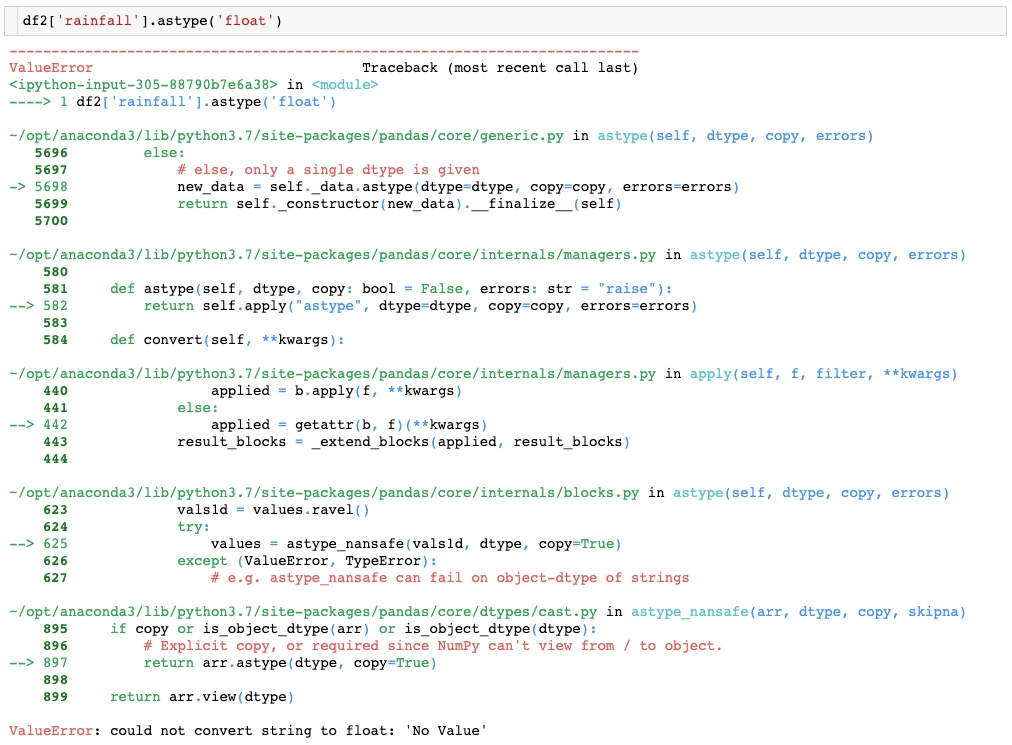

> This results in a `ValueError` which means the conversion of `rainfall` to `float64` data type did not work.

`astype()` works when the data is clean and when you want to convert a numeric to a string object. However, when the data is not homogeneous (i.e. `object`) or has characters, `astype` may not be the right way to change the data type of a column.

Let's look at the other options of converting data types (mentioned above) to see if we can fix these issues.

##### Custom Functions

We can write custom functions and then apply them to convert the data type of a column to an appropriate type. Let's change the data type of `drought` (dtype object) to `bool`.

```python
# Create function
def str2bool(val):
    """
    Converts a string data type to boolean
    - converts string values to lowercase
    - checks for multiple positive values
    - returns the correct boolean type
    """

    val = val.lower() # converts string value to lowercase
    if val in ("yes", "y", "true",  "t", "1"): # checks for multiple positive values
        return True
    return False
```

We can now use the `apply` function to apply the `str2bool` function to all values of the column.

Remember that simply applying a function to a column only returns a copy of the column. To ensure the change gets applied to the DataFrame, we need to assign it back.

```python
# Apply the function
df2['drought'] = df2['drought'].apply(str2bool)

# Check type
df2['drought'].dtype
```

```
dtype('bool')
```

```python
# Look at column values
df2['drought']
```

```
CA     True
TX     True
NY    False
FL     True
IL    False
Name: drought, dtype: bool
```

The beauty of custom functions is that they open up a gateway of opportunities. With a simple function, we could consider multiple string values such as `"yes", "y", "true", "t", "1"`. As a result, the column can essentially have any of these values and the function will return `True`.

This was just a simple function and much more complex functions can be written to address various issues in the data.

###### Using `np.where()`

Another popular approach that is useful for many types of problems is to use `np.where()` function. Let's convert the data type of `drought` back to `object` and then take a look at using `np.where()`.

```python
df2['drought'] = ['Y','Y','N','Y','N']
df2['drought'].dtype
```

```
dtype('O')
```

```python
# Use np.where()
df2['drought'] = np.where(df2['drought'] == 'Y', True, False)
```

```python
# Check values
df2['drought']
```

```
CA     True
TX     True
NY    False
FL     True
IL    False
Name: drought, dtype: bool
```

`np.where()` function converts all`Y` values to `True` and everything else is changed to `False`.

##### Pandas built-in functions

Pandas built-in helper functions, such as `to_numeric()` and `to_datetime()`, can be very useful for converting certain data type.

###### Convert `rainfall` column (type object) to `float`

```python
# Look at rainfall column
df2['rainfall']
```

```
CA        22.9
TX          35
NY       42.87
FL       54.73
IL    No Value
Name: rainfall, dtype: object
```

```python
# Check the data type of each value in the column
df2['rainfall'].apply(type)
```

```
CA      <class 'str'>
TX      <class 'int'>
NY    <class 'float'>
FL      <class 'str'>
IL      <class 'str'>
Name: rainfall, dtype: object
```

The `rainfall` column contains values of multiple different types, such as integers, floats and strings. Let's use the `to_numeric` function to change data type to `float64`.

```python
pd.to_numeric(df2['rainfall'], errors='coerce')
```

```
CA    22.90
TX    35.00
NY    42.87
FL    54.73
IL      NaN
Name: rainfall, dtype: float64
```

By passing `errors=coerce`, the function replaces the invalid “No Value” value with a `NaN`.

To ensure the change gets applied to the DataFrame, we need to assign it back. Here is another way of applying `to_numeric` using the `apply` function.

```python
df2['rainfall'] = df2['rainfall'].apply(pd.to_numeric, errors='coerce')
```

```python
df2['rainfall']
```

```
CA    22.90
TX    35.00
NY    42.87
FL    54.73
IL      NaN
Name: rainfall, dtype: float64
```

###### Convert `year, month, day` columns (type int) to `datetime64`

The `year, month, day` columns can be combined into a single new `date` column with the correct data type. Let's convert the date columns to `datetime64` type using `pd.to_datetime()`. We will dive into the details of individual date or time columns in a later section of this guide series.

```python
df2['date'] = pd.to_datetime(df2[['year','month','day']])
```

```python
df2['date']
```

```
CA   2019-02-27
TX   2019-05-12
NY   2020-07-10
FL   2019-09-07
IL   2020-11-17
Name: date, dtype: datetime64[ns]
```

Now, the data types of `df2` DataFrame are all cleaned up. Let's take a look.

```python
df2.dtypes
```

```
population           float64
land area            float64
density              float64
drought                 bool
year                   int64
month                  int64
day                    int64
gdp                  float64
rainfall             float64
date          datetime64[ns]
dtype: object
```

### Operating on DataFrames

**Pandas** is designed to work with **NumPy** and essentially inherits the ability to perform quick element-wise operations with basic arithmetic (add, subtract, multiply, etc.) and more sophisticated operations (trigonometric, exponential and logarithmic functions, etc.) from **NumPy**.

There are various other ways in which users can interact with the data in a **DataFrame**, such as reindexing data, dropping data, adding data, renaming columns etc. Let's explore how we can operate on the data in a DataFrame.

#### Arithmetic Operations

In **Pandas**,

- Unary ufuncs (operate on a single input): such as exponential and logarithmic functions, preserve index and column labels in the output.
- Binary ufuncs (operate on two inputs): such as addition and multiplication, automatically align indices and return a DataFrame whose index and columns are the unions of the ones in each DataFrame.

Let's create sample data to demonstrate this.

```python
# Create data
rng = np.random.RandomState(55)

df3 = pd.DataFrame(rng.randint(1,20,(3,3)), columns=list('bcd'),
                    index=['Ohio', 'Texas', 'Colorado'])
print('df3 is: \n', df3)

print()

df4 = pd.DataFrame(rng.randint(1,25,(4,3)), columns=list('bde'),
                   index=['Arizona', 'Ohio', 'Texas', 'Iowa'])
print('df4 is: \n', df4)
```

```
df3 is:
            b  c   d
Ohio      14  8   9
Texas      6  6   2
Colorado  17  4  15

df4 is:
           b   d   e
Arizona  14  13  16
Ohio      8   2  22
Texas    24   9  20
Iowa     11   8   1
```

##### Unary Operations

When applying a NumPy ufunc on DataFrame object, the result will be a Pandas object with the indices preserved.

```python
print('Exponentiation:\n', np.power(df3,2))
print()
print('Square Root:\n', np.sqrt(df3))
print()
print("ln(x)\n", np.log(df4))
```

```
Exponentiation:
             b   c    d
Ohio      196  64   81
Texas      36  36    4
Colorado  289  16  225

Square Root:
                  b         c         d
Ohio      3.741657  2.828427  3.000000
Texas     2.449490  2.449490  1.414214
Colorado  4.123106  2.000000  3.872983

ln(x)
                 b         d         e
Arizona  2.639057  2.564949  2.772589
Ohio     2.079442  0.693147  3.091042
Texas    3.178054  2.197225  2.995732
Iowa     2.397895  2.079442  0.000000
```

##### Binary Operations

Pandas will automatically align indices and return a DataFrame whose index and columns are the unions of the ones in each DataFrame.

```python
# Addition
df3 + df4
```

|  | b | c | d | e |
| --- | --- | --- | --- | --- |
| Arizona | NaN | NaN | NaN | NaN |
| Colorado | NaN | NaN | NaN | NaN |
| Iowa | NaN | NaN | NaN | NaN |
| Ohio | 22.0 | NaN | 11.0 | NaN |
| Texas | 30.0 | NaN | 11.0 | NaN |

Since the `c` and `e` columns are not found in both DataFrame objects, they appear as all missing in the result. The same holds for the rows whose labels are not common in both DataFrame.

We can also use **Pandas Methods** to perform arithmetic operations. Adding these DataFrame will result in **NA** values in the locations that don’t overlap.

```python
# Addition
df3.add(df4)
```

|  | b | c | d | e |
| --- | --- | --- | --- | --- |
| Arizona | NaN | NaN | NaN | NaN |
| Colorado | NaN | NaN | NaN | NaN |
| Iowa | NaN | NaN | NaN | NaN |
| Ohio | 22.0 | NaN | 11.0 | NaN |
| Texas | 30.0 | NaN | 11.0 | NaN |

```python
# Subtraction
df3 - df4
```

|  | b | c | d | e |
| --- | --- | --- | --- | --- |
| Arizona | NaN | NaN | NaN | NaN |
| Colorado | NaN | NaN | NaN | NaN |
| Iowa | NaN | NaN | NaN | NaN |
| Ohio | 6.0 | NaN | 7.0 | NaN |
| Texas | -18.0 | NaN | -7.0 | NaN |

```python
# Multiplication
df3 * df4
```

|  | b | c | d | e |
| --- | --- | --- | --- | --- |
| Arizona | NaN | NaN | NaN | NaN |
| Colorado | NaN | NaN | NaN | NaN |
| Iowa | NaN | NaN | NaN | NaN |
| Ohio | 112.0 | NaN | 18.0 | NaN |
| Texas | 144.0 | NaN | 18.0 | NaN |

```python
# Division
df3/df4
```

|  | b | c | d | e |
| --- | --- | --- | --- | --- |
| Arizona | NaN | NaN | NaN | NaN |
| Colorado | NaN | NaN | NaN | NaN |
| Iowa | NaN | NaN | NaN | NaN |
| Ohio | 1.75 | NaN | 4.500000 | NaN |
| Texas | 0.25 | NaN | 0.222222 | NaN |

##### Operations between DataFrame and Series

Operations between a DataFrame and a Series are similar to the operations between a two-dimensional and one-dimensional NumPy array. The index and column alignment is maintained when applying aritmatic operations between a DataFrame and a Series.

As an example, when we subtract a two-dimensional array and one of its rows, the subtraction is performed once for each row based on NumPy's broadcasting rules. Operations between a DataFrame and a Series are similar.

```python
# Get Data
df3
```

|  | b | c | d |
| --- | --- | --- | --- |
| Ohio | 14 | 8 | 9 |
| Texas | 6 | 6 | 2 |
| Colorado | 17 | 4 | 15 |

```python
# Subtract row for `Ohio` from df3
df3 - df3.iloc[0]
```

|  | b | c | d |
| --- | --- | --- | --- |
| Ohio | 0 | 0 | 0 |
| Texas | -8 | -2 | -7 |
| Colorado | 3 | -4 | 6 |

The resulting DataFrame shows element values when the row for `Ohio` gets subtracted from the DataFrame.

For operating on columns, you can use the object methods while specifying the `axis` keyword.

```python
df3.subtract(df3['c'], axis='columns')
```

|  | Colorado | Ohio | Texas | b | c | d |
| --- | --- | --- | --- | --- | --- | --- |
| Ohio | NaN | NaN | NaN | NaN | NaN | NaN |
| Texas | NaN | NaN | NaN | NaN | NaN | NaN |
| Colorado | NaN | NaN | NaN | NaN | NaN | NaN |

#### Reindexing Data

`reindex` is an important Pandas method that conforms the data to a new index. `reindex`, when applied to a `DataFrame`, can alter either the (row) index, columns, or both. Lets' take a look at reindexing.

```python
# Create data
df5 = pd.DataFrame(np.arange(9).reshape((3, 3)),
                    index=['a', 'c', 'e'],
                    columns=['CA', 'TX', 'OH'])
df5
```

|  | CA | TX | OH |
| --- | --- | --- | --- |
| a | 0 | 1 | 2 |
| c | 3 | 4 | 5 |
| e | 6 | 7 | 8 |

**Reindexing Rows**

```python
df5 = df5.reindex(['e','d','c','b','a'])
df5
```

|  | CA | TX | OH |
| --- | --- | --- | --- |
| e | 6.0 | 7.0 | 8.0 |
| d | NaN | NaN | NaN |
| c | 3.0 | 4.0 | 5.0 |
| b | NaN | NaN | NaN |
| a | 0.0 | 1.0 | 2.0 |

The index for this DataFrame is now updated. For the new indices `b and d` that were added with reindexing, Pandas has automatically generated `Nan` values.

**Reindexing Columns**

Columns can be reindexed using the `columns` keyword.

```python
df5 = df5.reindex(columns=['CA','OH','TX'])
df5
```

|  | CA | OH | TX |
| --- | --- | --- | --- |
| e | 6.0 | 8.0 | 7.0 |
| d | NaN | NaN | NaN |
| c | 3.0 | 5.0 | 4.0 |
| b | NaN | NaN | NaN |
| a | 0.0 | 2.0 | 1.0 |

**Reindexing Rows and Columns**

`reindex` can be used more succinctly by label-indexing with `loc`.

```python
df5 = df5.loc[['a','b','c','d','e'], ['TX','OH','CA']]
df5
```

|  | TX | OH | CA |
| --- | --- | --- | --- |
| a | 1.0 | 2.0 | 0.0 |
| b | NaN | NaN | NaN |
| c | 4.0 | 5.0 | 3.0 |
| d | NaN | NaN | NaN |
| e | 7.0 | 8.0 | 6.0 |

##### Reset Index

`reset_index()` can be used to reset the index of a DataFrame to a default index. This operations turns the index labels into columns and assigns a default numerical index to the DataFrame. To modify the DataFrame use `inplace=True`.

`reset_index()` comes in handy when working with data that has multiple levels of indexing. We will dig into the details of `MultiIndex` objects in the next part of this guide series. For now, let's take a quick look at how it works.

```python
df5.reset_index()
```

|  | index | TX | OH | CA |
| --- | --- | --- | --- | --- |
| 0 | a | 1.0 | 2.0 | 0.0 |
| 1 | b | NaN | NaN | NaN |
| 2 | c | 4.0 | 5.0 | 3.0 |
| 3 | d | NaN | NaN | NaN |
| 4 | e | 7.0 | 8.0 | 6.0 |

`drop` parameter can be used to avoid the old index being added as a column.

```python
df5.reset_index(drop=True)
```

|  | TX | OH | CA |
| --- | --- | --- | --- |
| 0 | 1.0 | 2.0 | 0.0 |
| 1 | NaN | NaN | NaN |
| 2 | 4.0 | 5.0 | 3.0 |
| 3 | NaN | NaN | NaN |
| 4 | 7.0 | 8.0 | 6.0 |

#### Dropping Data

Dropping rows or columns comes in handy when cleaning your data. The `drop()` function can be easily applied.

Functions that modify the size or shape of a DataFrame return a new object so that the original data remains unchanged. To apply changes to existing DataFrame, we need to either assign the function back to DataFrame or use `inplace` keyword.

**Dropping rows**

Calling drop with index labels will drop values from the row.

```python
# Drop rows
df5.drop(['b','d'])
```

|  | TX | OH | CA |
| --- | --- | --- | --- |
| a | 1.0 | 2.0 | 0.0 |
| c | 4.0 | 5.0 | 3.0 |
| e | 7.0 | 8.0 | 6.0 |

The result of `drop` operation is a new object as it does not modify the original DataFrame.

```python
df5
```

|  | TX | OH | CA |
| --- | --- | --- | --- |
| a | 1.0 | 2.0 | 0.0 |
| b | NaN | NaN | NaN |
| c | 4.0 | 5.0 | 3.0 |
| d | NaN | NaN | NaN |
| e | 7.0 | 8.0 | 6.0 |

To modify the DataFrame, we will use `inplace` keyword.

```python
df5.drop(['b','d'], inplace=True)
df5
```

|  | TX | OH | CA |
| --- | --- | --- | --- |
| a | 1.0 | 2.0 | 0.0 |
| c | 4.0 | 5.0 | 3.0 |
| e | 7.0 | 8.0 | 6.0 |

**Dropping Columns**

Columns can be dropped by passing a value to the `axis` keyword: `axis=1` or `axis='columns'`.

```python
df5.drop('CA', axis='columns')
```

|  | TX | OH |
| --- | --- | --- |
| a | 1.0 | 2.0 |
| c | 4.0 | 5.0 |
| e | 7.0 | 8.0 |

#### Adding Data

A key aspect of data exploration is to feature engineer the data i.e. add new features to the data. New columns can be easily added to a DataFrame using the following methods.

**Using Values in a List**

A new column can be added with default values from a list.

```python
df5['FL'] = [5,8,10]
df5
```

|  | TX | OH | CA | FL |
| --- | --- | --- | --- | --- |
| a | 1.0 | 2.0 | 0.0 | 5 |
| c | 4.0 | 5.0 | 3.0 | 8 |
| e | 7.0 | 8.0 | 6.0 | 10 |

The column for `FL` is now added to the end of the DataFrame.

**Using `insert()`**

`insert()` provides the flexibility to add a column at any index position. It also provides different options for inserting the column values. Let's add a new column for `NY` at index position `2` between `OH` and `CA`.

```python
df5.insert(loc=2, column='NY', value=[7,4,9])
df5
```

|  | TX | OH | NY | CA | FL |
| --- | --- | --- | --- | --- | --- |
| a | 1.0 | 2.0 | 7 | 0.0 | 5 |
| c | 4.0 | 5.0 | 4 | 3.0 | 8 |
| e | 7.0 | 8.0 | 9 | 6.0 | 10 |

**Using `assign()`**

`assign()` returns a new DataFrame object that has a copy of the original data with the requested changes. The original DataFrame remains unchanged. To apply changes to existing DataFrame, we need to assign the function back to the DataFrame.

```python
df5 = df5.assign(WA = [0,3,12])
```

```python
df5
```

|  | TX | OH | NY | CA | FL | WA |
| --- | --- | --- | --- | --- | --- | --- |
| a | 1.0 | 2.0 | 7 | 0.0 | 5 | 0 |
| c | 4.0 | 5.0 | 4 | 3.0 | 8 | 3 |
| e | 7.0 | 8.0 | 9 | 6.0 | 10 | 12 |

#### Renaming Columns

Real world data is messy. In your data exploration journey, you may come across column names that are not representative of the data or that are too long, or you may just want to standardize the names of columns in your dataset. Let's look at how we can rename columns.

**Using `rename()`**

`rename()` is quite useful when we need to rename some selected columns. Let's rename some columns to reflect the names of states.

```python
df5.rename(columns = {'TX':'Texas', 'OH':'Ohio'}, inplace=True)
```

```python
df5
```

|  | Texas | Ohio | NY | CA | FL | WA |
| --- | --- | --- | --- | --- | --- | --- |
| a | 1.0 | 2.0 | 7 | 0.0 | 5 | 0 |
| c | 4.0 | 5.0 | 4 | 3.0 | 8 | 3 |
| e | 7.0 | 8.0 | 9 | 6.0 | 10 | 12 |

**By assigning a list of Columns**

We can also assign a list of new names to the `columns` attribute of the DataFrame object. The caveat is that this method required *providing new names for all the columns* even if want to rename only a few.

```python
df5.columns = ['Texas', 'Ohio', 'New York', 'California', 'Florida', 'Washington']
```

```python
df5
```

|  | Texas | Ohio | New York | California | Florida | Washington |
| --- | --- | --- | --- | --- | --- | --- |
| a | 1.0 | 2.0 | 7 | 0.0 | 5 | 0 |
| c | 4.0 | 5.0 | 4 | 3.0 | 8 | 3 |
| e | 7.0 | 8.0 | 9 | 6.0 | 10 | 12 |

### Working with Missing Data

Missing data occurs in many applications as real world data in rarely clean. It is generally referred to as *Null, NaN, or NA values*. Assessing the missing data is an important process, as it can identify potential problems or biases that may arise as a result of the missing data. There are various useful methods for detecting, removing, and replacing null values in **Pandas** such as:

- `isnull()`: generates a boolean mask indicating missing values.
- `notnull()`: generates a boolean mask indicating non-missing values.
- `dropna()`: drops null values and returns a filtered version of the data.
- `fillna()`: returns a copy of the data with missing values filled or imputed.
- `interpolate()`: powerful function that providers various interpolation techniques to fill the missing values.

Let's start by looking at the types of missing data in Pandas and then we will explore how to detect, filter, drop and impute missing data.

#### Missing Data in Pandas

**Pandas** uses two already existing Python null values:

- `None` - is a Python singleton object only used in arrays with data type 'object'.
- `NaN` - is a special floating point value.

##### `None` object

```python
v1 = np.array([1, None, 4, 6])
v1
```

```
array([1, None, 4, 6], dtype=object)
```

`dtype=object` shows NumPy inferred that the contents of this array are Python objects. Any operations on the data will be done at the Python level, which are typically slower than the arrays with native types.

```python
for dtype in ['object', 'int', 'float']:
    print("dtype =", dtype)
    %timeit np.arange(1E4, dtype=dtype).sum()
    print()
```

```
dtype = object
391 µs ± 5.76 µs per loop (mean ± std. dev. of 7 runs, 1000 loops each)

dtype = int
11.2 µs ± 708 ns per loop (mean ± std. dev. of 7 runs, 100000 loops each)

dtype = float
11.2 µs ± 653 ns per loop (mean ± std. dev. of 7 runs, 100000 loops each)
```

*Aggregation* operations on an array with `None` value results in an error.

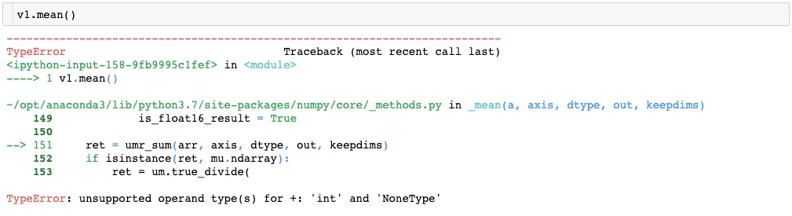

##### `NaN`: Not a Number

```python
v2 = np.array([1, np.NaN, 4, 6])
v2.dtype
```

```
dtype('float64')
```

`dtype('float64')` shows NumPy inferred that the contents of this array are native floating-point type. Unlike `object`, this array supports faster operations.

*Aggregation* operations on an array with `NaN` will result in a `NaN`.

```python
v2.sum(), v2.mean()
```

```
(nan, nan)
```

##### `NaN` and `None`

**Pandas** handles both `NaN` and `None` interchangeably and automatically converts them as appropriate.

```python
pd.Series([1, np.nan, 5, None])
```

```
0    1.0
1    NaN
2    5.0
3    NaN
dtype: float64
```

Pandas automatically converts `None` to a `NaN` value.

#### Detect Missing Data

`isnull()` and `notnull()` methods can be used to detect and filter missing data. We will start by creating some data to apply these methods.

```python
# Create data
df6 = df3 + df4
df6.loc['Ohio','c'] = 10
df6.loc['Colorado','b'] = 5
df6
```

|  | b | c | d | e |
| --- | --- | --- | --- | --- |
| Arizona | NaN | NaN | NaN | NaN |
| Colorado | 5.0 | NaN | NaN | NaN |
| Iowa | NaN | NaN | NaN | NaN |
| Ohio | 22.0 | 10.0 | 11.0 | NaN |
| Texas | 30.0 | NaN | 11.0 | NaN |

```python
df6.isnull()
```

|  | b | c | d | e |
| --- | --- | --- | --- | --- |
| Arizona | True | True | True | True |
| Colorado | False | True | True | True |
| Iowa | True | True | True | True |
| Ohio | False | False | False | True |
| Texas | False | True | False | True |

The result shows a matrix of True or False values based on the presence of null values in data.

##### Missing values in each column

Chaining a `sum()` method returns a summation of missing values in each column.

```python
df6.isnull().sum()
```

```
b    2
c    4
d    3
e    5
dtype: int64
```

##### Missing values in DataFrame

Chaining two `sum()` methods will return the total number of missing values in the DataFrame.

```python
df6.isnull().sum().sum()
```

```
14
```

##### Using `notnull()`

`notnull()` is the opposite of `isnull()` and can be used to check the number of non-missing values.

```python
df6.notnull().sum()
```

```
b    3
c    1
d    2
e    0
dtype: int64
```

```python
# Total non-missing values in dataframe
df6.notnull().sum().sum()
```

```
6
```

#### Visualize Misisng Data

It is important to understand the pattern of occurrence of missing values before we decide to drop or impute missing data. An easy way to visualize missing records is to use `heatmap()` from the seaborn library.

```python
# Import Seaborn
import seaborn as sns
```

```python
# Get Data
df6
```

|  | b | c | d | e |
| --- | --- | --- | --- | --- |
| Arizona | NaN | NaN | NaN | NaN |
| Colorado | 5.0 | NaN | NaN | NaN |
| Iowa | NaN | NaN | NaN | NaN |
| Ohio | 22.0 | 10.0 | 11.0 | NaN |
| Texas | 30.0 | NaN | 11.0 | NaN |

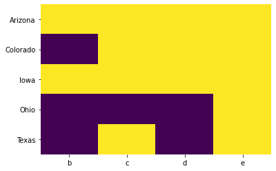

```python
# Visualize missing
sns.heatmap(df6.isnull(), cbar=False, cmap='viridis')
```

Missing records are displayed in **yellow** color.

#### Filter based on Missing Data

Both `isnull()` and `notnull()` can be applied to columns of a DataFrame to filter out rows with missing and non-missing data.

```python
# Get data
df6
```

|  | b | c | d | e |
| --- | --- | --- | --- | --- |
| Arizona | NaN | NaN | NaN | NaN |
| Colorado | 5.0 | NaN | NaN | NaN |
| Iowa | NaN | NaN | NaN | NaN |
| Ohio | 22.0 | 10.0 | 11.0 | NaN |
| Texas | 30.0 | NaN | 11.0 | NaN |

Filter rows where values in column `b` are null.

```python
df6[df6['b'].isnull()]
```

|  | b | c | d | e |
| --- | --- | --- | --- | --- |
| Arizona | NaN | NaN | NaN | NaN |
| Iowa | NaN | NaN | NaN | NaN |

Filter rows where values in column `b` are not null.

```python
df6[df6['b'].notnull()]
```

|  | b | c | d | e |
| --- | --- | --- | --- | --- |
| Colorado | 5.0 | NaN | NaN | NaN |
| Ohio | 22.0 | 10.0 | 11.0 | NaN |
| Texas | 30.0 | NaN | 11.0 | NaN |

#### Drop Missing Data

`dropna()` method allows us to drop any missing values from the data. The method returns a copy of the DataFrame, so to apply the changes inplace, use `inplace=True`.

```python
# Get data
df6
```

|  | b | c | d | e |
| --- | --- | --- | --- | --- |
| Arizona | NaN | NaN | NaN | NaN |
| Colorado | 5.0 | NaN | NaN | NaN |
| Iowa | NaN | NaN | NaN | NaN |
| Ohio | 22.0 | 10.0 | 11.0 | NaN |
| Texas | 30.0 | NaN | 11.0 | NaN |

By default, `dropna()` will drop all rows in which any null value is present.

```python
df6.dropna()
```

|  | b | c | d | e |
| --- | --- | --- | --- | --- |

Since all rows of `df6` have some NA values, the result is an empty copy of the DataFrame. Alternatively, using `axis='columns'` drops all columns containing a null value.

```python
df6.dropna(axis='columns')
```

| Arizona |
| --- |
| Colorado |
| Iowa |
| Ohio |
| Texas |

Since all columns have some NA values, the result is an empty copy of the DataFrame.

`dropna()` provides the flexibility to drop rows or columns with all NA values, or a majority of NA values using **`how`** or **`thresh`** parameters. The default `how='any'`, allows any row or column containing a null value to be dropped. To only drop rows or columns that have all null values, `how='all'` can be specified.

```python
# Drop rows with all null values
df6.dropna(how='all')
```

|  | b | c | d | e |
| --- | --- | --- | --- | --- |
| Colorado | 5.0 | NaN | NaN | NaN |
| Ohio | 22.0 | 10.0 | 11.0 | NaN |
| Texas | 30.0 | NaN | 11.0 | NaN |

```python
# Drop columns with all null values
df6.dropna(how='all', axis='columns')
```

|  | b | c | d |
| --- | --- | --- | --- |
| Arizona | NaN | NaN | NaN |
| Colorado | 5.0 | NaN | NaN |
| Iowa | NaN | NaN | NaN |
| Ohio | 22.0 | 10.0 | 11.0 |
| Texas | 30.0 | NaN | 11.0 |

**`thresh`** parameter allows you specify a minimum number of non-null values a row/column should have to be kept in the result.

```python
df6.dropna(thresh=2)
```

|  | b | c | d | e |
| --- | --- | --- | --- | --- |
| Ohio | 22.0 | 10.0 | 11.0 | NaN |
| Texas | 30.0 | NaN | 11.0 | NaN |

Only rows with 2 or more non-null values are kept, and since the row for `Colorado` has only 1 non-null value, it is dropped.

```python
df6.dropna(thresh=2, axis='columns')
```

|  | b | d |
| --- | --- | --- |
| Arizona | NaN | NaN |
| Colorado | 5.0 | NaN |
| Iowa | NaN | NaN |
| Ohio | 22.0 | 11.0 |
| Texas | 30.0 | 11.0 |

Similarly, column `c` has only 1 non-null value and is therefore dropped.

#### Impute Missing Data

Rather than dropping NA values and potentially discarding some other data with it, you may just want to replace them with a value such as 0, or some other imputation such as mean or median of the data. Pandas `fillna()` method can be used for such operations. The method returns a new object, but you can modify the existing object in-place.

```python
# Get data
df6
```

|  | b | c | d | e |
| --- | --- | --- | --- | --- |
| Arizona | NaN | NaN | NaN | NaN |
| Colorado | 5.0 | NaN | NaN | NaN |
| Iowa | NaN | NaN | NaN | NaN |
| Ohio | 22.0 | 10.0 | 11.0 | NaN |
| Texas | 30.0 | NaN | 11.0 | NaN |

##### Fill with a Constant Value

Calling `fillna()` with a constant value replaces missing values with that value.

```python
df6.fillna(0)
```

|  | b | c | d | e |
| --- | --- | --- | --- | --- |
| Arizona | 0.0 | 0.0 | 0.0 | 0.0 |
| Colorado | 5.0 | 0.0 | 0.0 | 0.0 |
| Iowa | 0.0 | 0.0 | 0.0 | 0.0 |
| Ohio | 22.0 | 10.0 | 11.0 | 0.0 |
| Texas | 30.0 | 0.0 | 11.0 | 0.0 |

##### Forawrd and Backward Fill

Forward and backward fill can be used to propagate the previous value forward (`ffill`) or next values backward (`bfill`). We can specify an `axis` along which the fill method will operate.

**Note**: If a previous value is not available during a fill operation, the NA value remains.

```python
# Forward fill along rows
df6.fillna(method='ffill')
```

|  | b | c | d | e |
| --- | --- | --- | --- | --- |
| Arizona | NaN | NaN | NaN | NaN |
| Colorado | 5.0 | NaN | NaN | NaN |
| Iowa | 5.0 | NaN | NaN | NaN |
| Ohio | 22.0 | 10.0 | 11.0 | NaN |
| Texas | 30.0 | 10.0 | 11.0 | NaN |

```python
# Forward fill along columns
df6.fillna(method='ffill', axis='columns')
```

|  | b | c | d | e |
| --- | --- | --- | --- | --- |
| Arizona | NaN | NaN | NaN | NaN |
| Colorado | 5.0 | 5.0 | 5.0 | 5.0 |
| Iowa | NaN | NaN | NaN | NaN |
| Ohio | 22.0 | 10.0 | 11.0 | 11.0 |
| Texas | 30.0 | 30.0 | 11.0 | 11.0 |

```python
# Backward fill along rows
df6.fillna(method='bfill')
```

|  | b | c | d | e |
| --- | --- | --- | --- | --- |
| Arizona | 5.0 | 10.0 | 11.0 | NaN |
| Colorado | 5.0 | 10.0 | 11.0 | NaN |
| Iowa | 22.0 | 10.0 | 11.0 | NaN |
| Ohio | 22.0 | 10.0 | 11.0 | NaN |
| Texas | 30.0 | NaN | 11.0 | NaN |

##### Fill with Arithmetic or Aggregate Functions

A mean, median, mode, max or min value for the column can be used to fill missing values.

```python
# Get data
df6
```

|  | b | c | d | e |
| --- | --- | --- | --- | --- |
| Arizona | NaN | NaN | NaN | NaN |
| Colorado | 5.0 | NaN | NaN | NaN |
| Iowa | NaN | NaN | NaN | NaN |
| Ohio | 22.0 | 10.0 | 11.0 | NaN |
| Texas | 30.0 | NaN | 11.0 | NaN |

```python
# Fill with mean
df6.fillna(df6.mean())
```

|  | b | c | d | e |
| --- | --- | --- | --- | --- |
| Arizona | 19.0 | 10.0 | 11.0 | NaN |
| Colorado | 5.0 | 10.0 | 11.0 | NaN |
| Iowa | 19.0 | 10.0 | 11.0 | NaN |
| Ohio | 22.0 | 10.0 | 11.0 | NaN |
| Texas | 30.0 | 10.0 | 11.0 | NaN |

```python
# Fill with median
df6.fillna(df6.median())
```

|  | b | c | d | e |
| --- | --- | --- | --- | --- |
| Arizona | 22.0 | 10.0 | 11.0 | NaN |
| Colorado | 5.0 | 10.0 | 11.0 | NaN |
| Iowa | 22.0 | 10.0 | 11.0 | NaN |
| Ohio | 22.0 | 10.0 | 11.0 | NaN |
| Texas | 30.0 | 10.0 | 11.0 | NaN |

```python
# Fill with max
df6.fillna(df6.max())
```

|  | b | c | d | e |
| --- | --- | --- | --- | --- |
| Arizona | 30.0 | 10.0 | 11.0 | NaN |
| Colorado | 5.0 | 10.0 | 11.0 | NaN |
| Iowa | 30.0 | 10.0 | 11.0 | NaN |
| Ohio | 22.0 | 10.0 | 11.0 | NaN |
| Texas | 30.0 | 10.0 | 11.0 | NaN |

##### Fill using a Dictionary of Values

A dictionary of constant values or aggregate functions can be passed to fill missing values in columns differently.

```python
df6
```

|  | b | c | d | e |
| --- | --- | --- | --- | --- |
| Arizona | NaN | NaN | NaN | NaN |
| Colorado | 5.0 | NaN | NaN | NaN |
| Iowa | NaN | NaN | NaN | NaN |
| Ohio | 22.0 | 10.0 | 11.0 | NaN |
| Texas | 30.0 | NaN | 11.0 | NaN |

```python
fill_value = {'b': df6['b'].median(),
              'd': df6['d'].mean(),
              'e': 1}
df6.fillna(value=fill_value)
```

|  | b | c | d | e |
| --- | --- | --- | --- | --- |
| Arizona | 22.0 | NaN | 11.0 | 1.0 |
| Colorado | 5.0 | NaN | 11.0 | 1.0 |
| Iowa | 22.0 | NaN | 11.0 | 1.0 |
| Ohio | 22.0 | 10.0 | 11.0 | 1.0 |
| Texas | 30.0 | NaN | 11.0 | 1.0 |

##### Using `interpolate()`

`interpolate()` is a very powerful function that providers various interpolation techniques (linear, quadratic, polynomial etc.) to fill the missing values. Let's take a quick look, and you can learn more about `interpolate()` [here](https://pandas.pydata.org/pandas-docs/stable/reference/api/pandas.DataFrame.interpolate.html).

```python
# Get data
df6
```

|  | b | c | d | e |
| --- | --- | --- | --- | --- |
| Arizona | NaN | NaN | NaN | NaN |
| Colorado | 5.0 | NaN | NaN | NaN |
| Iowa | NaN | NaN | NaN | NaN |
| Ohio | 22.0 | 10.0 | 11.0 | NaN |
| Texas | 30.0 | NaN | 11.0 | NaN |

`interpolate()` using Linear method. Note that Linear method ignores the index and treats the values as equally spaced.

```python
df6.interpolate(method='linear', limit_direction='forward')
```

|  | b | c | d | e |
| --- | --- | --- | --- | --- |
| Arizona | NaN | NaN | NaN | NaN |
| Colorado | 5.0 | NaN | NaN | NaN |
| Iowa | 13.5 | NaN | NaN | NaN |
| Ohio | 22.0 | 10.0 | 11.0 | NaN |
| Texas | 30.0 | 10.0 | 11.0 | NaN |

## Conclusion

In this part of the guide series we introduced **[Pandas](https://pandas.pydata.org/)**, a Python package that builds on **[NumPy](https://numpy.org/)** and provides data structures and functions designed to make working with structured data fast, easy, and expressive.

You have seen how `DataFrame` can be created and then data can be accessed using `loc` and `iloc` operators. We discussed in detail how to check the different data types in a DataFrame and ways to change these data types. We also discussed how to perform various operations on a `DataFrame` (i.e. Arithmetic, Reindex, Add and Drop data) and to work with missing data. We briefly introduced working with a `Series` object as well.

In the next part of this guide series, you will learn about how to be more productive with Pandas. We will discuss data aggregation, transformation operations, multi-level indexing and working with time series data.

## References

[1] Wes McKinney. 2017. Python for Data Analysis: Data Wrangling with Pandas, NumPy, and IPython (2nd. ed.). O'Reilly Media, Inc.

[2] Jake VanderPlas. 2016. Python Data Science Handbook: Essential Tools for Working with Data (1st. ed.). O'Reilly Media, Inc.

[3] https://pbpython.com/pandas_dtypes.html